# Lab 3: Gesture Recognition using Convolutional Neural Networks

### Part (c) - 5 pt

Train your new network, including any hyperparameter tuning. Plot and submit the training curve of your best model only.

Note: Depending on how you are caching (saving) your AlexNet features, PyTorch might still be tracking updates to the **AlexNet weights**, which we are not tuning. One workaround is to convert your AlexNet feature tensor into a numpy array, and then back into a PyTorch tensor.

```python
tensor = torch.from_numpy(tensor.detach().numpy())
```

```python
###################################### Reworking the previous functions to better suit our needs ##############################################
def get_accuracy_alexnet(model, train, test):
    # Determining which dataset we're training
    if train == True and test == False:
      dataloader = trainingAlexNetFeatures
    elif train == False and test == False:
      dataloader = validationAlexNetFeatures
    elif train == False and test == True:
      dataloader = testAlexNetFeatures

    correct = 0
    total = 0

    for imgs, labels in dataloader:

        #############################################
        #To Enable GPU Usage
        if use_cuda and torch.cuda.is_available():
          device = torch.device("cuda")
          model.cuda()
        else:
          device = torch.device("cpu")

        imgs = imgs.to(device)
        labels = labels.to(device)
        #############################################

        output = model(imgs)

        #select index with maximum prediction score
        pred = output.max(1, keepdim=True)[1]
        correct += pred.eq(labels.view_as(pred)).sum().item()
        total += imgs.shape[0]

    return correct / total

def train_alexnet(model, dataloader, num_epochs, lr, batch_size, testModel):
    criterion = nn.CrossEntropyLoss()
    optimizer = optim.SGD(model.parameters(), lr=lr, momentum=0.9)

    iters, losses, train_acc, val_acc = [], [], [], []

    # training
    numberIterations = 0 # the number of iterations
    for epoch in range(num_epochs):
        for imgs, labels in iter(dataloader):
            #############################################
            #To Enable GPU Usage
            if use_cuda and torch.cuda.is_available():
              device = torch.device("cuda")
              model.cuda()
            else:
              device = torch.device("cpu")

            imgs = imgs.to(device)
            labels = labels.to(device)
            #############################################

            out = model(imgs)             # forward pass
            loss = criterion(out, labels) # compute the total loss
            loss.backward()               # backward pass (compute parameter updates)
            optimizer.step()              # make the updates for each parameter
            optimizer.zero_grad()         # a clean up step for PyTorch

            # save the current training information
            iters.append(numberIterations)
            losses.append(float(loss)/batch_size)               # compute *average* loss

            if  testModel == False:                      # only compute validation acc for larger dataset
              train_acc.append(get_accuracy_alexnet(model, train=True, test=False))   # compute training accuracy
              val_acc.append(get_accuracy_alexnet(model, train=False, test=False))  # compute validation accuracy
            elif testModel == True:
              train_acc.append(get_accuracy_alexnet(model, train=False, test=True))

            numberIterations += 1

    # plotting
    plt.title("Loss Curve")
    plt.plot(iters, losses, label="Train")
    plt.xlabel("Iterations")
    plt.ylabel("Loss")
    plt.show()

    plt.title("Training Accuracy Curve")
    plt.plot(iters, train_acc, label="Train")
     # Only plot our validation curve if our val_acc isn't empty (this is because I didn't split my smaller dataset up into train/val)
    if len(val_acc) != 0:
        plt.plot(iters, val_acc, label="Validation")
    plt.xlabel("Iterations")
    plt.ylabel("Accuracy")
    plt.legend(loc='best')
    plt.show()

    print("Final Training Accuracy: {}".format(train_acc[-1]))
    if len(val_acc) != 0:
      print("Final Validation Accuracy: {}".format(val_acc[-1]))
```

[output not shown]

[output cut: 341 more lines]

[output not shown]

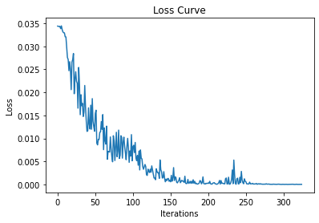

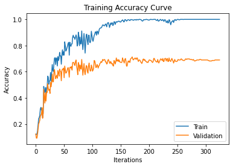

```
Final Training Accuracy: 1.0
Final Validation Accuracy: 0.689922480620155
```

```python
model = CNN_AlexnetFeatures()
numEpochsAlex = 25
batchSizeAlex = 64

# Training AlexNet:
train_alexnet(model=model, dataloader=trainingAlexNetFeatures, num_epochs=numEpochsAlex, lr=learningRate, batch_size=batchSizeAlex, testModel=False)
```